# ChIP-seq In Bioconductor

Rockefeller University, Bioinformatics Resource Centre

http://rockefelleruniversity.github.io/RU_ChIPseq/

# ChIP-seq introduction

Chromatin precipitation followed by deep sequencing (**ChIP-seq**) is a well established technique which allows for the genome wide identification of transcription factor binding sites and epigenetic marks.

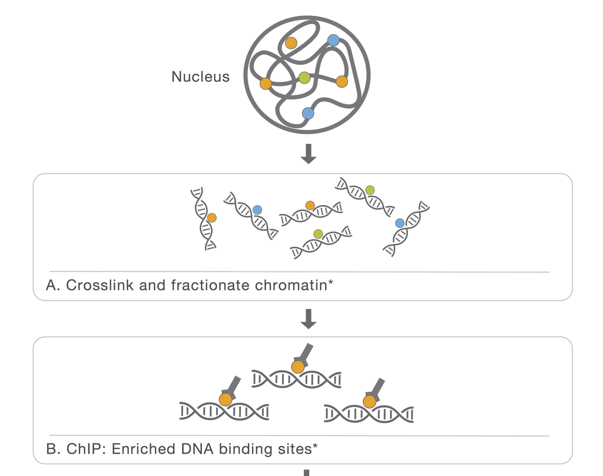

# Raw Sequence data.

Our raw ChIP-seq sequencing data will be in FASTQ format.

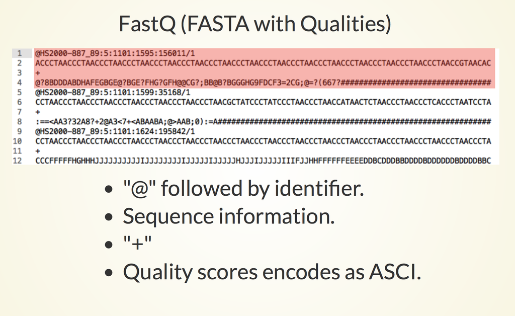

# Working with raw ChIPseq sequence data.

Once we have downloaded the raw fastQ data we can use the [ShortRead package](https://bioconductor.org/packages/release/bioc/html/ShortRead.html) to review our sequence data quality.

We have reviewed how to work with raw sequencing data in the [**FastQ in Bioconductor** session.](https://rockefelleruniversity.github.io/Bioconductor_Introduction/r_course/presentations/slides/FastQInBioconductor.html#1)

First we load the [ShortRead library.](https://bioconductor.org/packages/release/bioc/html/ShortRead.html)

```r
library(ShortRead)
```

# Working with raw ChIPseq sequence data.

First we will review the raw sequencing reads using functions in the [ShortRead package.](https://bioconductor.org/packages/release/bioc/html/ShortRead.html)

We however do not need to review all reads in the file to can gain an understanding of data quality. We can simply review a subsample of the reads and save ourselves some time and memory.

Note when we subsample we retrieve random reads from across the entire fastQ file. This is important as fastQ files are often ordered by their position on the sequencer.

# Working with raw ChIPseq sequence data.

We can subsample from a fastQ file using functions in **ShortRead** package.

Here we use the [**FastqSampler** and **yield** function](https://rockefelleruniversity.github.io/Bioconductor_Introduction/r_course/presentations/slides/FastQInBioconductor.html#39) to randomly sample a defined number of reads from a fastQ file. Here we subsample 1 million reads.

```r
fqSample <- FastqSampler("~/Downloads/ENCFF001NQP.fastq.gz",n=10^6)
fastq <- yield(fqSample)
```

# Working with raw ChIPseq sequence data.

The resulting object is a [ShortReadQ object](https://rockefelleruniversity.github.io/Bioconductor_Introduction/r_course/presentations/slides/FastQInBioconductor.html#9) showing information on the number of cycles, base pairs in reads, and number of reads in memory.

```r
fastq
```

```
## class: ShortReadQ
## length: 1000000 reads; width: 36 cycles
```

# Working with raw ChIPseq sequence data.

If we wished, we can assess information from the fastQ file using our [familiar accessor functions.](https://rockefelleruniversity.github.io/Bioconductor_Introduction/r_course/presentations/slides/FastQInBioconductor.html#13)

- **sread()** - Retrieve sequence of reads.
- **quality()** - Retrieve quality of reads as ASCI scores.
- **id()** - Retrieve IDs of reads.

```r
readSequences <- sread(fastq)
readQuality <- quality(fastq)
readIDs <- id(fastq)
readSequences
```

```
##   A DNAStringSet instance of length 1000000
##           width seq
##       [1]    36 GCCCAATCCCCGCCAATGCCGTAGTTCAAGATGGTG
##       [2]    36 CCATCCACAGGTGTTTATCTAGATTTACAATGCCAA
##       [3]    36 TATGGCAAGAAAACTGAAACTCATGGAAAAAGAGAA
##       [4]    36 GGGCTNGTGCCTAGCAGCCTACGCCCTTAGGTGTGT
##       [5]    36 GAATATGGGTTGTTTTCCTCAGAATTAAGGAGAGTA
##       ...   ... ...
##  [999996]    36 GTCGTCAAGTGGATGTTTCTCATTTTCCATGATTTT
##  [999997]    36 AGAAAAAAATATAGATATAAACTTAAGTGTGAGTGT
##  [999998]    36 AATGCCGATGGCATCAAGGATCAGGGCGCTCCAAAC
##  [999999]    36 AACTTTTATGGTCTGGACATATAGCTGAGAGGTAGA
## [1000000]    36 ACTCTGTTGACTTCACCACACAGGGCCATATACTTG
```

# Quality with raw ChIPseq sequence data.

We can check some simple quality metrics for our subsampled fastQ data.

First we can review the overall reads’ quality scores.

We use the [**alphabetScore()** function with our read’s qualitys](https://rockefelleruniversity.github.io/Bioconductor_Introduction/r_course/presentations/slides/FastQInBioconductor.html#26) to retrieve the sum quality for every read from our subsample.

```r
readQuality <- quality(fastq)
readQualities <- alphabetScore(readQuality)
readQualities[1:10]
```

```
##  [1] 1090 1156 1123  988 1083 1202  776 1146 1193  886
```

# Quality with raw ChIPseq sequence data.

We can then produce a histogram of quality scores to get a better understanding of the distribution of scores.

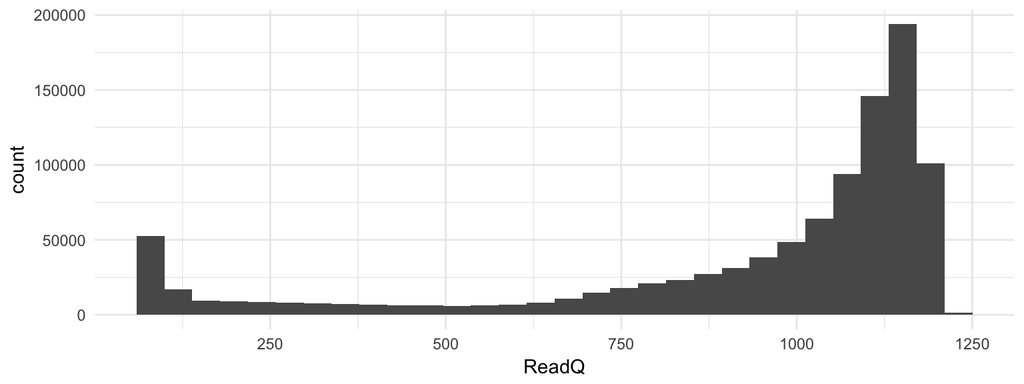

```r
library(ggplot2)
toPlot <- data.frame(ReadQ=readQualities)
ggplot(toPlot,aes(x=ReadQ))+geom_histogram()+theme_minimal()
```

# Base frequency with raw ChIPseq sequence data.

We can review the occurrence of DNA bases within reads and well as the occurrence of DNA bases across sequencing cycles using the [**alphabetFrequency()**](https://rockefelleruniversity.github.io/Bioconductor_Introduction/r_course/presentations/slides/FastQInBioconductor.html#16) and [**alphabetByCycle()**](https://rockefelleruniversity.github.io/Bioconductor_Introduction/r_course/presentations/slides/FastQInBioconductor.html#26) functions respectively.

Here we check the overall frequency of **A, G, C, T and N (unknown bases)** in our sequence reads.

```r
readSequences <- sread(fastq)
readSequences_AlpFreq <- alphabetFrequency(readSequences)
readSequences_AlpFreq[1:3,]
```

```
##       A  C G  T M R W S Y K V H D B N - + .
## [1,]  8 12 9  7 0 0 0 0 0 0 0 0 0 0 0 0 0 0
## [2,] 11  9 5 11 0 0 0 0 0 0 0 0 0 0 0 0 0 0
## [3,] 19  4 8  5 0 0 0 0 0 0 0 0 0 0 0 0 0 0
```

# Base frequency with raw ChIPseq sequence data.

Once we have the frequency of DNA bases in our sequence reads we can retrieve the sum across all reads.

```r
summed__AlpFreq  <- colSums(readSequences_AlpFreq)
summed__AlpFreq[c("A","C","G","T","N")]
```

```
##        A        C        G        T        N
## 10037892  7842276  7650424 10101604   367804
```

# Assessment by cycle with raw ChIPseq sequence data.

We can review DNA base occurrence by cycle using the [**alphabetByCycle()** function.](https://rockefelleruniversity.github.io/Bioconductor_Introduction/r_course/presentations/slides/FastQInBioconductor.html#26)

```r
readSequences_AlpbyCycle <- alphabetByCycle(readSequences)
readSequences_AlpbyCycle[1:4,1:10]
```

```
##         cycle
## alphabet   [,1]   [,2]   [,3]   [,4]   [,5]   [,6]   [,7]   [,8]   [,9]
##        A 307372 327857 282689 275672 277082 277364 279166 282071 271199
##        C 179051 174321 205912 223451 210668 220691 213260 217673 220245
##        G 242252 246451 226817 212719 212329 214249 210269 209711 213887
##        T 267159 247965 279685 278749 290377 278517 288136 279620 284069
##         cycle
## alphabet  [,10]
##        A 279821
##        C 222377
##        G 210121
##        T 277070
```

# Assessment by cycle with raw ChIPseq sequence data.

We often plot this to visualise the base occurrence over cycles to observe any bias. First we arrange the base frequency into a data frame.

```r
AFreq <- readSequences_AlpbyCycle["A",]
CFreq <- readSequences_AlpbyCycle["C",]
GFreq <- readSequences_AlpbyCycle["G",]
TFreq <- readSequences_AlpbyCycle["T",]
toPlot <- data.frame(Count=c(AFreq,CFreq,GFreq,TFreq),
                     Cycle=rep(1:36,4),
                     Base=rep(c("A","C","G","T"),each=36))
```

# Assessment by cycle with raw ChIPseq sequence data.

Now we can plot the frequencies using ggplot2

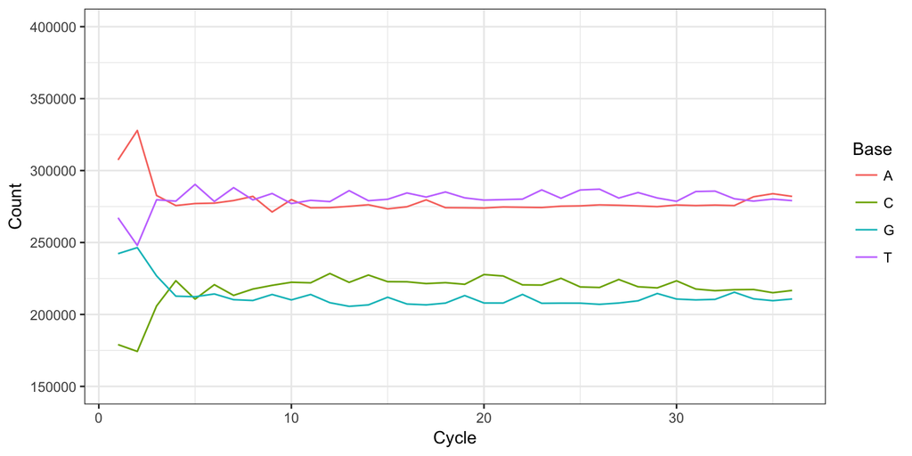

```r
ggplot(toPlot,aes(y=Count,x=Cycle,colour=Base))+geom_line()+
  theme_bw()
```

# Assessment by cycle with raw ChIPseq sequence data.

We can also assess mean read quality over cycles. This will allow us to identify whether there are any isses with quality dropping off over time.

For this we use the [**as(*read_quality*,“matrix”)**](https://rockefelleruniversity.github.io/Bioconductor_Introduction/r_course/presentations/slides/FastQInBioconductor.html#27) function first to translate our ASCI quality scores to numeric quality scores.

```r
qualAsMatrix <- as(readQuality,"matrix")
qualAsMatrix[1:2,]
```

```
##      [,1] [,2] [,3] [,4] [,5] [,6] [,7] [,8] [,9] [,10] [,11] [,12] [,13]
## [1,]   32   33   34   33   29   13   29   33   32    34    34    24    33
## [2,]   33   33   34   33   33   33   32   33   33    34    31    29    33
##      [,14] [,15] [,16] [,17] [,18] [,19] [,20] [,21] [,22] [,23] [,24]
## [1,]    33    29    28    33    33    33    31    30    33    33    32
## [2,]    31    33    33    32    31    32    32    33    31    28    33
##      [,25] [,26] [,27] [,28] [,29] [,30] [,31] [,32] [,33] [,34] [,35]
## [1,]    24    32    28    30    33    29    26    29    28    30    30
## [2,]    32    33    33    32    31    32    33    32    29    31    33
##      [,36]
## [1,]    30
## [2,]    32
```

# Assessment by cycle with raw ChIPseq sequence data.

We can now [visualise qualities across cycles using a boxplot.](https://rockefelleruniversity.github.io/Bioconductor_Introduction/r_course/answers/fastq_answers.html)

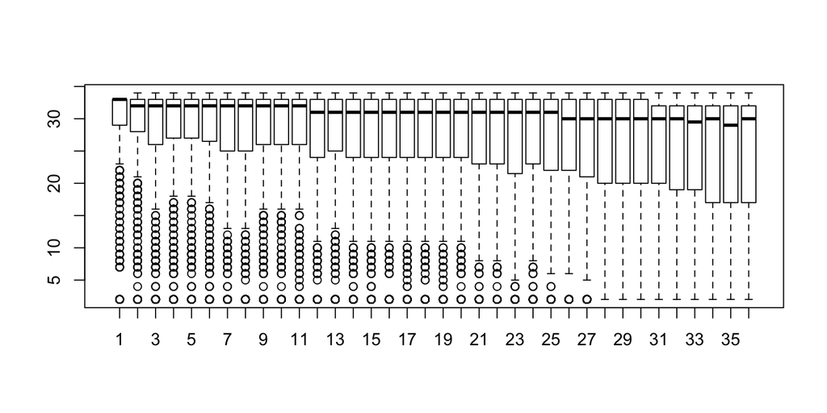

```r
boxplot(qualAsMatrix[1:1000,])
```

# Assessment by cycle with raw ChIPseq sequence data.

In this case the distribution of reads quality scores and read qualities over time look okay. We will often want to access fastQ samples together to see if any samples stick out by these metrics.

Here we observed a second population of low quality scores so will remove some reads with low quality scores and high unknown bases.

# Filtering data

We will want to conserve our memory usage to [allow us to deal with loading large files.](https://rockefelleruniversity.github.io/Bioconductor_Introduction/r_course/presentations/slides/FastQInBioconductor.html#40)

Here we set up a **FastqStreamer object** to read in 100000 reads at a time.

```r
fqStreamer <- FastqStreamer("~/Downloads/ENCFF001NQP.fastq.gz",
                            n=100000)
```

# Filtering data

Now we [loop through file](https://rockefelleruniversity.github.io/Bioconductor_Introduction/r_course/presentations/slides/FastQInBioconductor.html#41), filter reads and [write out a FastQ](https://rockefelleruniversity.github.io/Bioconductor_Introduction/r_course/presentations/slides/FastQInBioconductor.html#37) of our filtered reads

```r
TotalReads <- 0
TotalReadsFilt <- 0
while (length(fq <- yield(fqStreamer))>0) {
    TotalReads <- TotalReads+length(fq)
    filt1 <- fq[alphabetScore(fq) > 300 ]
    filt2 <- filt1[alphabetFrequency(sread(filt1))[,"N"] < 10]
    TotalReadsFilt <- TotalReadsFilt+length(filt2)
    writeFastq(filt2,"filtered_ENCFF001NQP.fastq.gz",mode="a")
}
TotalReads
TotalReadsFilt
```

# Creating a reference genome.

First we need to retrieve the sequence information for the genome of interest in [FASTA format](https://rockefelleruniversity.github.io/Genomic_Data/genomicFileFormats.html#/6)

We can use the [BSgenome libraries to retrieve the full sequence information.](https://rockefelleruniversity.github.io/Bioconductor_Introduction/r_course/presentations/slides/SequencesInBioconductor.html#4)

For the mouse mm10 genome we load the package **BSgenome.Mmusculus.UCSC.mm10**.

```r
library(BSgenome.Mmusculus.UCSC.mm10)
BSgenome.Mmusculus.UCSC.mm10
```

```
## Mouse genome:
## # organism: Mus musculus (Mouse)
## # provider: UCSC
## # provider version: mm10
## # release date: Dec. 2011
## # release name: Genome Reference Consortium GRCm38
## # 66 sequences:
## #   chr1                 chr2                 chr3
## #   chr4                 chr5                 chr6
## #   chr7                 chr8                 chr9
## #   chr10                chr11                chr12
## #   chr13                chr14                chr15
## #   ...                  ...                  ...
## #   chrUn_GL456372       chrUn_GL456378       chrUn_GL456379
## #   chrUn_GL456381       chrUn_GL456382       chrUn_GL456383
## #   chrUn_GL456385       chrUn_GL456387       chrUn_GL456389
## #   chrUn_GL456390       chrUn_GL456392       chrUn_GL456393
## #   chrUn_GL456394       chrUn_GL456396       chrUn_JH584304
## # (use 'seqnames()' to see all the sequence names, use the '$' or '[['
## # operator to access a given sequence)
```

# Creating a reference genome.

```r
writeXStringSet(mainChrSeqSet,
                "BSgenome.Mmusculus.UCSC.mm10.mainChrs.fa")
```

# QuasR genomic with BSGenome object

We can now align our data by using the **qAlign()** function.

The **qAlign()** function requires the path to our sample table file and the path of a FASTA file to align sequence reads against.

```r
library(QuasR)
qAlign("sampleTable.txt","BSgenome.Mmusculus.UCSC.mm10.mainChrs.fa")
```

# Aligning ChIPseq reads with Rsubread.

The **Rsubread** package offers a faster aligner than the QuasR package although the **Rsubread** package is only available on Mac OS and Linux.

For alignment with the **Rsubread** package we must first build our genome index for Rsubread using the **buildindex()** function.

The [**buildindex()** function simply takes the parameters of our desired index name and the FASTA file to build index from.](https://rockefelleruniversity.github.io/Bioconductor_Introduction/r_course/presentations/slides/AlignmentInBioconductor.html#34)

```r
library(Rsubread)
buildindex("BSgenome.Mmusculus.UCSC.mm10.mainChrs",
           "BSgenome.Mmusculus.UCSC.mm10.mainChrs.fa")
```

# Sort and index reads.

As before, we sort and index our files using the [**Rsamtools** packages **sortBam()** and **indexBam()** functions respectively.](https://rockefelleruniversity.github.io/Bioconductor_Introduction/r_course/presentations/slides/AlignedDataInBioconductor.html#10)

The resulting sorted and indexed BAM file is now ready for use in external programs such as IGV as well as for further downstream analysis in R.

```r
library(Rsamtools)
sortBam("filtered_ENCFF001NQP.bam","SR_Myc_Mel_rep1")
indexBam("SR_Myc_Mel_rep1.bam")
```

# Mapped reads.

Now we have the index for the BAM file, we can retrieve and plot the number of mapped reads using [the **idxstatsBam()** function.](https://rockefelleruniversity.github.io/Bioconductor_Introduction/r_course/presentations/slides/AlignedDataInBioconductor.html#15)

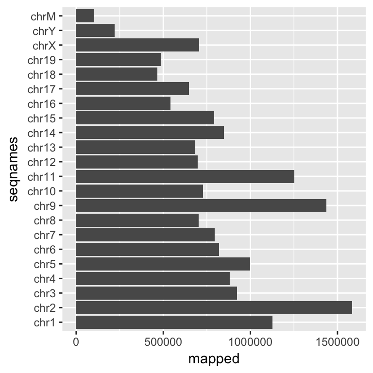

```r
mappedReads <- idxstatsBam("../../../SR_Myc_Mel_rep1.bam")
TotalMapped <- sum(mappedReads[,"mapped"])
ggplot(mappedReads,aes(x=seqnames,y=mapped))+
  geom_bar(stat="identity")
```

# Create a bigWig

We can also create a bigWig from our sorted, indexed BAM file to allow us to quickly review our data in IGV.

First we use the [**coverage()** function to create an **RLElist object** containing our coverage scores.](https://rockefelleruniversity.github.io/Bioconductor_Introduction/r_course/presentations/slides/Summarising_Scores_In_Bioconductor.html#13)

```r
forBigWig <- coverage("SR_Myc_Mel_rep1.bam")
forBigWig
```

# Create a bigWig

We can now export our [**RLElist object** as a bigWig using the **rtracklayer** package’s **export.bw()** function.](https://rockefelleruniversity.github.io/Bioconductor_Introduction/r_course/presentations/slides/GenomicScores_In_Bioconductor.html#40)

```r
library(rtracklayer)
export.bw(forBigWig,con="SR_Myc_Mel_rep1.bw")
```

# BAM and bigWig

[figure not shown]

# Time for an exercise.

Link_to_exercises

Link_to_answers